# Homework 5

Jacob Harrell

3/30/2021

**Question 1**

First load the data and then place into an unmarkedFrameOccu object.

```r
setwd("C:/Users/Jacob/Desktop/HW5")
bob<-read.csv(file = 'Bobcat.csv')

library(unmarked)
bob_mat <- as.matrix(bob)
occu_data <- unmarkedFrameOccu(y = bob_mat)
```

**Question 2**

Fit an occupancy model with the assumption that conditional detection probability is a function of the number of people photographed at a site and that the occupancy probability is a function of disturbances within 5 km of a site.

```r
p_covs <- read.csv("p covariates.csv")

det_covs <- list(people = data.frame(p_covs))

site_covs <- read.csv('psi covariates.csv')

occu_data2 <- unmarkedFrameOccu(y = bob_mat, siteCovs = site_covs, obsCovs = det_covs)
fit <- occu(formula = ~ people ~ Dist_5km, data = occu_data2)
summary(fit)
```

```
##
## Call:
## occu(formula = ~people ~ Dist_5km, data = occu_data2)
##
## Occupancy (logit-scale):
##             Estimate    SE      z  P(>|z|)
## (Intercept)    -1.05 0.101 -10.39 2.63e-25
## Dist_5km      -23.64 4.773  -4.95 7.28e-07
##
## Detection (logit-scale):
##             Estimate     SE       z P(>|z|)
## (Intercept)  -3.0133 0.0741 -40.646   0.000
## people       -0.0609 0.3779  -0.161   0.872
##
## AIC: 4462.98
## Number of sites: 1951
## optim convergence code: 0
## optim iterations: 39
## Bootstrap iterations: 0
```

**Question 3**

Interpret the effect of the number of people photographed at each site on the conditional detection probability of bobcat. Verify through r.

```r
betas <- coef(fit)
betas
```

```
##      psi(Int) psi(Dist_5km)        p(Int)     p(people)
##   -1.04584568  -23.64383918   -3.01330391   -0.06088908
```

```r
p_1 <- plogis(betas[3]+betas[4]*1)
p_1
```

```
##     p(Int)
## 0.04418441
```

```r
p_2 <- plogis(betas[3]+betas[4]*2)
p_2
```

```
##     p(Int)
## 0.04168313
```

```r
log((p_2/(1-p_2))/(p_1/(1-p_1)))
```

```
##      p(Int)
## -0.06088908
```

For every one unit change within the variable ‘people’, the log odds of success of detecting a bobcat decreases by .0609.

**Question 4**

Re-create the Wald test for the effect of disturbance within 5 km. Define the null hypothesis and note whether we would reject it or fail to reject it.

```r
disturb <- -23.64 / 4.773 #coefficient for dist_5km divided by its standard error
disturb
```

```
## [1] -4.95286
```

```r
2 * pnorm(-1 * abs(disturb))
```

```
## [1] 7.313065e-07
```

**Question 5**

Predict and plot the effect of disturbance within 5 km on bobcat occupancy probability over the range of observed disturbance within 5 km.

```r
new_psi <- data.frame(Dist_5km = seq(from = min(site_covs$Dist_5km),
                                to = max(site_covs$Dist_5km),
                                length.out = 100)
)

prd <- predict(object = fit, newdata = new_psi, type = 'state')
head(prd)
```

```
##   Predicted         SE     lower     upper
## 1 0.2600236 0.01935982 0.2239054 0.2997182
## 2 0.2540944 0.01855293 0.2194710 0.2921356
## 3 0.2482550 0.01782171 0.2149896 0.2848002
## 4 0.2425062 0.01716846 0.2104579 0.2777182
## 5 0.2368486 0.01659480 0.2058736 0.2708941
## 6 0.2312826 0.01610146 0.2012363 0.2643305
```

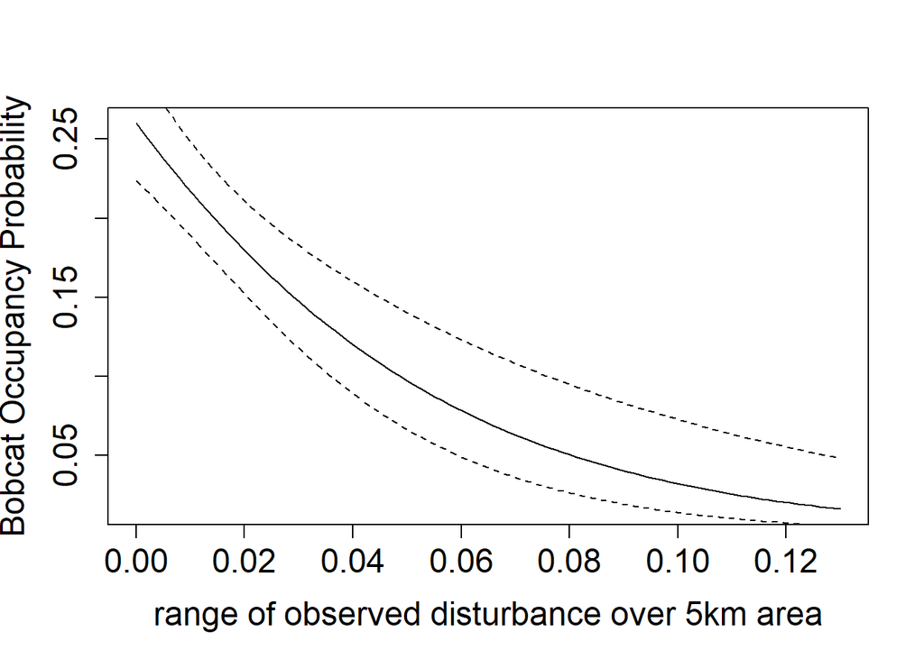

```r
plot(y= prd$Predicted, x = new_psi$Dist_5km,
     ylab = 'Bobcat Occupancy Probability',
     xlab = 'range of observed disturbance over 5km area',
     cex.axis = 1.5,
     cex.lab = 1.5,
     type = 'l')
lines(y = prd$lower, x = new_psi$Dist_5km, lty = 2)
lines(y = prd$upper, x = new_psi$Dist_5km, lty = 2)
```